# Problem 1: Multiple Choice

# Problem 5: Markov Chain

Let $ W =$ Workday and $ D = $ Day Off. We observe the following sequence of Workdays and Days Off:

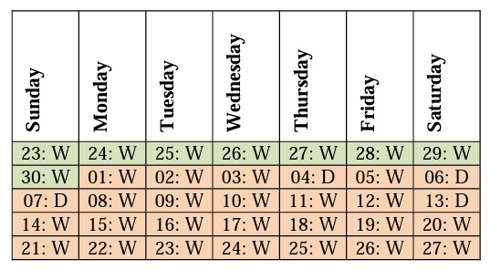

Note: Sunday the $23^{rd}$ will be considered the first day (i.e., $\text{Day } 1$).

a) What is the probability that the first day is a workday (i.e., $P(\text{Day } 1 = \text{Workday})$)

b) What is the probability that the first day is a day off (i.e., $P(\text{Day }1 = \text{Day Off})$)

c) What is the probability that today will be a workday given that yesterday was a workday (i.e., $P(\text{Day } t = \text{Workday} \mid \text{Day } t-1 = \text{Workday})$)

d) What is the probability that today will be a day off given that yesterday was a workday (i.e., $P(\text{Day } t = \text{Day off} \mid \text{Day } t-1 = \text{Workday})$)

e) What is the probability that today will be a workday given that yesterday was a day off (i.e., $P(\text{Day } t = \text{Workday} \mid \text{Day } t-1 = \text{Day Off})$)

f) What is the probability that today will be a day off given that yesterday was a day off (i.e., $P(\text{Day } t = \text{Day Off} \mid \text{Day } t-1 = \text{Day Off})$)

g) Bulid the state trasition probability matrix.

# Problem 6: LSTM

Recall the LSTM architecture. Suppose you want the memory cell to sum its inputs over time. What values should the input gate and forget gate take? You do not need to justify your answer.

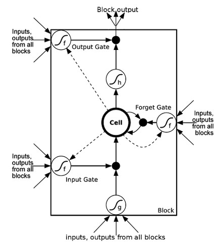

# Problem 7: Statistical Anomaly Detection

Let $P = (0,0),Q = (1,0),R = (0,3) ∈ R^2$, and $f : R^2 → R^2$ be an isometry such that $ f(P) = (0,2), f(Q) = (−1,2) $and $f(R) = (0,5)$. Consider the points $S =(−3,0)$.

Hint 1: Isometry is a distance-preserving transformation between metric spaces

Hint 2: For isometry, following equations are satisfied:

$$ \begin{align*} d(P,S) &= d(f(P),f(S))\\ d(Q,S) &= d(f(Q),f(S))\\ d(R,S) &= d(f(R),f(S)) \end{align*}$$

a) Find the Euclidean distances $d(P,S),d(Q,S),d(R,S)$

b) Find the image $f(S)$ of the point $S ∈ R^2$.

c) Pick a point among $P, Q, R$ with the highest probability of being an anomaly based on its distance from $S$ in a sense of Euclidean distances.

# Problem 8: Self-supervised Learning

a) Prof. Lee has explained about various pretext tasks you can use for the self-supervised learning. Choose one pretext task and explain the mechanism of that pretext task for self-supervised learning in detail. (Exclude the Rotation Network)

b) Draw the model (network) used in the pretext task chosen at (1) and explain in detail (Specify the function of each part of the model)

c) Explain downstream tasks that the pretext task specified at (1) can be applied

# Problem 9: PINN

Cost function of PINN can be written as below. Describe what each terms in the cost function means when the given ODE system is $ {u^\prime} = f(u,t)$ with $t \in [0, 1]$ and a known initial condition $u(0) = u_0$. $ {\text{NN}(t)}$ is the solution by a neural network.

$${L(\omega)} = \sum_{i} \left(\frac{d \text{NN}(t_i)}{dt}-f(\text{NN}(t_i),t_i)\right)^2 + (\text{NN}(0)-u_0)^2 $$

# Problem 10: Graph

Show the adjacency matrix $A$ and draw the graph with edges and nodes for the following questions

a) Undirected Graph

$\quad V$ = {1, 2, 3, 4, 5, 6, 7}

$\quad E$ = {{1,2}, {1,6}, {2,3}, {3,4}, {3,6}, {3,7}, {4,7}, {5,6}}

b) Directed Graph

$\quad V$ = {1, 2, 3, 4, 5, 6, 7}

$\quad E$ = {{1,2}, {1,6}, {2,3}, {3,4}, {3,7}, {4,7}, {6,3}, {6,5}}

# Problem 11: GCN

a) Define three situations (problems) where you can apply Graph Convolution Network

b) For the three situation mentioned above, write which task among the three task type of Graph Neural Network each situation belongs to and explain why.

c) Describe two commonalities and two differences that GCNs have with CNNs

# Problem 12: GCN

In the GCN layer, feature representation for layer $k+1$ can be written as $ H^{(k+1)} = \sigma (AH^{(k)} W^{(k)}) $.

a) By adding message passing with self-loops and neighborhood normalization on the equation, derive the final equation of feature representation for layer $k+1$

b) Describe briefly about the roles of message passing with self-loops and neighborhood normalization